# Occupational Mobility May 2022 Revised

Ken-Hou Lin

23 May, 2022

# Overview

This memo outlines the first draft of the paper. While there are clearly some novel findings, I am still thinking through how to best frame this paper. We will also have to decide whether these results are interesting and how to present them in a simple and effective manner.

# Framing of the Paper

## Occupational Mobility

Occupational mobility has attracted constant interest because occupations are important social units that organize the division of labor and the allocation of economic and social rewards.

Three main strains of study have considered the issue of occupational mobility.

The first examines the extent the amount of occupational mobility has changed over time (or differs by pre-labor market characteristics, such as race, gender, and education credential). The analysis is often conducted at the aggregate and examines how the amount has changed over time. Little attention is paid to how mobility varies across various between-occupation pathways.

The second strain does not examine mobility directly but views social closure as a key mechanism through which some occupations garner great resources. By setting up barriers of entry, such as licensing and educational requirements, to reduce the supply of labor, these occupations could demand for higher wages and status.

The third strain conceptualizes occupations as bundles of tasks that require different sets of skills. From this perspective, workers are more likely to transition between occupations that consist of similar tasks.

These perspectives tend to focus on the societal, institutional, or skill constraints on occupational mobility, assuming that individual workers would otherwise obtain more valued occupations.

## Mobility and Workplace

This study argues that the flow of labor does not merely reflect the constrained optimization for higher rewards but is also facilitated, or even constructed, by organizational process. That is, we should think about mobility as a result of structure (staffing patterns) as much as a result of agency.

Occupations that commonly share the same workplace tend to have greater mobility in-between.

At the individual level, the idea that workplace co-presence could promote between-occupation mobility is intuitive. By closely interacting with workers of different occupations, one could obtain occupation-specific knowledge or skills, social capital, aspiration, know-how, which lower the cost of transitioning into a different occupations.

At the organization level, it is also common for firms to construct occupational pipelines among workers through on-the-job training, promotion ladders, internal labor markets, or HR policies, which facilitate the replacement of workers while retaining firm-specific human capital.

(These will all be purely speculative but should be organized)

A “weak” proposition would be:

**1. Workplace co-presence is positively correlated with between-occupation mobility net of aforementioned constraints.**

A “strong” proposition would be:

**2. Workplace co-presence can account for a large portion of total occupational mobility net of aforementioned constraints.**

(On this note, do we need to consider reversed causality or spurious correlation between co-presence and mobility? Is there an argument to be made that occupational mobility can shape staffing patterns?)

## Boundary Conditions

The effect of workplace co-presence could depend on certain parameters. First, we would expect the effect to be greater for lateral and upward mobility than downward mobility due to “nominal rigidity” – both workers and the firms resist demotion (probably even more than departure). This does not mean that co-presence does not promote downward mobility in some situations such as transition out of labor force or reduced labor force participation.

**3. The association between co-presence and mobility is greater for lateral and upward mobility than for downward mobility**

Second, as Matt mentioned, institutional constraints could be so strong that they render co-presence irrelevant. This is particularly the case when the destination occupations require a large amount of training/investment. That said, I do know a dental assistant on her path to obtain the requirements for becoming a dentist, and work experience seems to matter. On the flip side, we would expect the effect of co-presence to be stronger for occupations that do not require a large amount of education/investment (which is in fact the majority of occupations).

**4. The association between co-presence and mobility could be weak when the destination requires substantial amount of formal training**

**5. The association between co-presence and mobility is stronger when the destination does not require substantial amount of formal training**

## Implications

Before diving into the data and a variety of results, I think it is necessary to first specify the potential implications. This could be the most important part of the paper.

There are two primary implications I can see at the moment. The first is about “who’s responsible for mobility?” The predominant view assigns the responsibility to individual workers, demanding them to invest in additional training for upward mobility. In the meantime, on-the-job training has declined and firms do not generate as much opportunity for workers to advance compared to before.

The second is linked to the workplace restructuring as shown in Elizabeth’s paper and the management literature. Although we do not have the data to show the long-run relation between restructuring and decline in mobility, our finding could be suggestive that the two are connected. As outsourcing/contracting becomes more popular, these strategies erect organizational boundaries between occupations, which reduce upward mobility/supply and generate greater between-occupation wage inequality.

A third possible implication is about how new work arrangement may impact mobility. This is a bit of a stretch but I wonder how remote work could change what sharing a workplace actually involves. If anything it can be a future research direction. We are simply showing that co-presence promotes mobility but not any specific mechanisms. If the association is more about the frequency of personal interaction, we may expect the association to be weaker with less interaction. If the association is more about firm HR policies, then the association should remain stable.

# Data

The overall structure of the data is quite similar to what I have described before. There are two main changes.

The first is that we now have a cross-sectional data set (2014-2017) with more occupational categories (n=187). Since the aggregate trend we observed in the previous iteration is mostly about the Great Recession, I believe having more categories is a good trade off.

Again, we are dropping the diagonal from the analysis since most workers remain in the same occupation in two consecutive years even when we use more detailed occupations. Including the diagonal will dramatically bend the estimates towards our prediction regarding homophily.

It should be noted that all estimates are weighted using the size of the origin occupation.

## Mobility & Co-presence

I will start by examining the correlation between co-presence and mobility. Some of these results probably don’t need to be in the paper.

### By Mobility Type

I separate all dyads into three types of mobility:

- Downward: Destination median wage is lower than 90% of the origin median wage.
- Lateral: Destination median wage is between 90% and 110% of the origin median wage.
- Upward: Destination median wage is higher than 110% of the origin median wage.

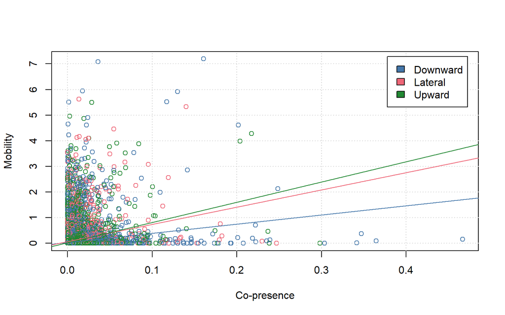

```r
pair<-read_dta("CPS_OES.dta")


pair$col<-0
pair$col[pair$mob_type==1]<-1
pair$col[pair$mob_type==2]<-2
pair$col[pair$mob_type==3]<-3
plot(pair$exp,pair$flow,xlab="Co-presence",ylab="Mobility",col=pcolor1[pair$col])
grid()

down<-subset(pair,pair$col==1)
lat<-subset(pair,pair$col==2)
up<-subset(pair,pair$col==3)

d_reg<-lm(flow ~ exp, data = down,w=sendsize)
l_reg<-lm(flow ~ exp, data = lat,w=sendsize)
u_reg<-lm(flow ~ exp, data = up,w=sendsize)

abline(d_reg, col=pcolor1[1])
abline(l_reg, col=pcolor1[2])
abline(u_reg, col=pcolor1[3])

legend("topright",c("Downward","Lateral","Upward"),inset=0.025, fill=pcolor1[c(1:3)])
```

The pattern confirms our expectation that co-presence is least correlated with mobility when facing an occupation with a significantly lower median wage. The correlation is strongest for upward mobility.

### By Education

Here I see how the correlation between co-presence and mobility varies by educational barriers. I classify the occupations into 4 classes based on the mode of education.

- **Professional**: The modal worker has a postgraduate degree.
- **College**: The modal worker has a 4-year college degree.
- **Vocational**: Not in the previous 2 groups but some amount of training (O*NET Job Zone 3)
- **Non-credential**: Any other occupations.

This creates 16 possible combinations for mobility. We would expect that mobility to be higher among occupations within the same class. It’s probably higher among less-credential occupations and college occupations than professional occupations since the latter are more specialized.

Regarding the correlation, the expectation is that co-presence will have stronger effects on the diagonal and strongest for N to N cell.

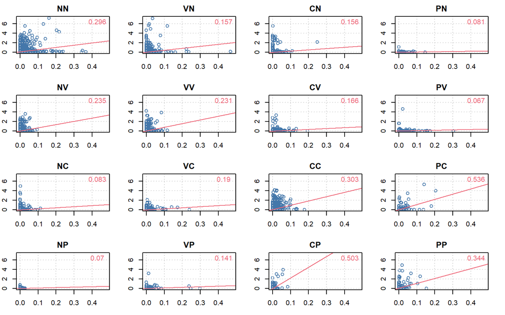

```r
par(mfcol=c(4,4),mar=c(3,2,2,2))
type<-c("NN" ,"NV" ,"NC" ,"NP" ,
               "VN" ,"VV" ,"VC" ,"VP",
               "CN" ,"CV" ,"CC" ,"CP",
               "PN" ,"PV" ,"PC" ,"PP")
xmax<-max(pair$exp)+0.01
ymax<-max(pair$flow)+0.01

for (i in 1:16){
  sub<-subset(pair,pair$edu_type==i)

  plot(sub$exp,sub$flow,xlab="Co-presence",ylab="Mobility",col=pcolor1[1],
       ylim=c(0,ymax),xlim = c(0,xmax),main=type[i])
   grid()
  reg<-lm(flow ~ exp, data = sub,w=sendsize)

  abline(reg, col=pcolor1[2])
  text(xmax*0.9,ymax*0.9,round(cor(sub$exp,sub$flow),3),col=pcolor1[2])

  box()
}
```

To clarify, the first letter stands for the origin occupation and the second letter stands for the destination occupation. For example, **NN** stands for from a non-credential occupation to another non-credential occupation. It should be noted that many occupations are non-credential. The number on the top right is the correlation coefficient.

Now that we have more detailed categories, the results in general are more sensible but there are also some interesting patterns.

First, for workers from non-credential occupations, co-presence clearly has a stronger effect for them to move to another non-credential or a vocational occupation than to a college or professional occupation. This is expected, as education could be a significant barrier.

Second, co-presence has a stronger effect for moving from a non-credential occupation to a vocational occupation than the other way around. This suggests that co-presence encourages more training and upward mobility.

Third, among the four categories, a college degree seems to be the main barrier.

Fourth, For workers from college occupations, co-presence in fact has a stronger effect for moving to a professional occupation than to another college occupation. Similarly, for workers from professional occupations, co-presence has a stronger effect for moving to a college occupation than to another professional occupation.

These results are a bit curious. It could be that having a college degree or not remains to main divide in the labor market as a whole. There are simply not many occupations that require post-graduate degree.

Let me look into some examples of college to professional transition:

```r
sub<-subset(pair,pair$edu_type==12)

sub$flow_rank<-rank(sub$flow)
top<-subset(sub,sub$flow>2)
knitr::kable(cbind(top$send_lab,top$receive_lab,top$flow), col.names = c("Send","Receive","Flow"))
```

| Send | Receive | Flow |
| --- | --- | --- |
| Social workers | Counselors | 2.98828143495491 |
| Miscellaneous community and social service specialists, including health educators and community health workers | Counselors | 3.90182974815231 |
| Miscellaneous community and social service specialists, including health educators and community health workers | Clergy and religious workers | 2.2435999780572 |
| Preschool and kindergarten teachers | Elementary and middle school teachers | 2.55342897518674 |
| Other teachers and instructors | Elementary and middle school teachers | 3.03278226909952 |

It seems to be mostly in the social service sector, where degree requirement is still not very rigid.

Some examples of professional to college transition:

```r
sub<-subset(pair,pair$edu_type==15)

sub$flow_rank<-rank(sub$flow)
top<-subset(sub,sub$flow>2)
knitr::kable(cbind(top$send_lab,top$receive_lab,top$flow), col.names = c("Send","Receive","Flow"))
```

| Send | Receive | Flow |
| --- | --- | --- |
| Education administrators | Managers, all other | 2.38614113630564 |
| Medical and health services managers | Managers, all other | 2.5954909513414 |
| Counselors | Social workers | 3.48097277337355 |
| Counselors | Miscellaneous community and social service specialists, including health educators and community health workers | 2.21174810997496 |
| Physical and occupational therapists | Registered nurses and nurse practitioners | 5.33247653003986 |
| Therapists, all other | Registered nurses and nurse practitioners | 3.98157684136315 |

The list looks quite reasonable to me. The majority of managers probably don’t have a post-grad degree. Clearly, we may still have some resolution problems but we have pushed to have as many categories as the data sources allow.

# Model Estimates

## Main Model

I estimate the following model:

$$F_{i->j}=O_{i->j}+|D_{i}-D_{j}|+C_{j}+|S_{i}-S_{j}|$$

Where $F_{i->j}$ denotes the directional flow from Occupation i to Occupation j, measured as the number of workers in Occupation j at t+1 over the number of workers in Occupation i at t times 100 (per 100 workers). $O_{i->j}$ denotes the proportion of co-workers of people in Occupation i are in Occupation j.

The three sets of covariates included, $D$, $C$, and $S$, mean to capture the three sets of constraints mentioned at the beginning. In theory, they should all have negative coefficients.

$D$ captures the absolute difference between i and j in % of workers who are men and % White.

$C$ captures two labor market institutions about the destination that facilitate social closure, including the absolute difference in the average years of education and % workers reporting their jobs require a license.

$S$ captures the absolute differences in a variety of general skill requirements, including Quantitative, Analytic, Creative, Interactive, Supervisory, Spatial, and Motion Control. All skill measures are standardized so each unit represents one standard deviation. This is more so a kitchen sink approach, clearly. I do not include Verbal skill because it’s highly correlated with educational difference.

An obvious complication when estimating a regression with our data set is that the observations are non-independent. I will report two “P-values.” The first is with origin clustered SE. The second is a percentile generated using the QAP procedure with 1,000 iterations/bootstraps, where values >0.95 or <0.05 indicate statistical significance. The two yield quite similar results.

```r
t1<-read.csv("table_all.csv")
qap<-read_dta("dist_qap_all.dta")
qap<-as.matrix(qap)
coef<-read_dta("coef_all.dta")
coef<-as.numeric(coef[1,])

t1<-cbind(t1,NA)
colnames(t1)<-c("Variable","Coefficent","Clstr SE P-value","QAP Percentile")


lab<-c("% Male"," % White","Average Yr EDUC","% Licenced",
       "Quantiative","Analytic","Creative","Interactive","Supervisory",
       "Spatial","Control")
loc<-2+length(lab)
t1[2:loc,1]<-c("Co-presence",lab)

for (i in 1:12){
  percentile <- ecdf(qap[,i])
  ptile<-percentile(coef[i])
  t1[i+1,4]<-ptile
}


knitr::kable(t1)
```

| Variable | Coefficent | Clstr SE P-value | QAP Percentile |
| --- | --- | --- | --- |
| = | =flow | = | NA |
| Co-presence | =4.461*** | =(0.000) | 1.000 |
| % Male | =-0.0855*** | =(0.000) | 0.000 |
| % White | =0.0222 | =(0.123) | 0.818 |
| Average Yr EDUC | =-0.0129*** | =(0.000) | 0.000 |
| % Licenced | =-0.0105 | =(0.167) | 0.210 |
| Quantiative | =-0.0146*** | =(0.000) | 0.000 |
| Analytic | =-0.00195 | =(0.467) | 0.311 |
| Creative | =-0.00442* | =(0.038) | 0.104 |
| Interactive | =-0.00389 | =(0.145) | 0.140 |
| Supervisory | =-0.0188*** | =(0.000) | 0.000 |
| Spatial | =-0.00433 | =(0.078) | 0.126 |
| Control | =-0.0104*** | =(0.000) | 0.006 |
| =_cons | =0.154*** | =(0.000) | NA |
| =N | =34782 | = | NA |
| =R-sq | =0.087 | = | NA |
| =p-values in parentheses |  |  | NA |
| =* p<0.05, ** p<0.01, *** p<0.001 |  |  | NA |

The estimates here are mostly consistent with the expectation. We see that co-presence is correlated with higher mobility net of a battery of control variables.

We do not see that the license requirement deters mobility, though the direction of coefficient is as expected.

Quantitative, creative, supervisory, and motion control skill differences are related to lower mobility but not analytic, interactive, and spatial orientation skill differences. Again, to me, this is just a kitchen sink approach to make sure that the coefficient for co-presence is conservative, not driven by workers of similar skill sets are more likely to work together.

An interesting, and perhaps existential, question to me is how much mobility would decline if we assign all co-presence with 0s. This would help us understand how much of the observed mobility could be attributed to co-presence.

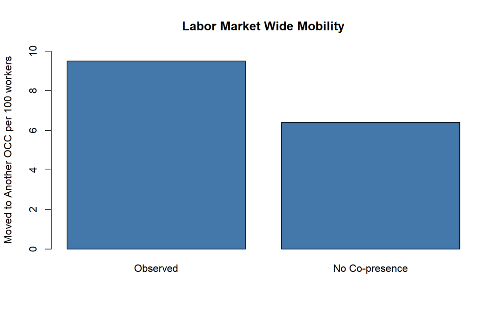

```r
cf<-read_dta("counterfactual_all.dta")


ob<-weighted.mean(cf$ob, cf$sendsize)


noexp<-weighted.mean(cf$cf_exp, cf$sendsize)
dif<-ob-noexp



barplot(cbind(ob,noexp),
        col=pcolor1,names.arg = c("Observed","No Co-presence")
        ,ylab="Moved to Another OCC per 100 workers",
        ylim=c(0,10), main="Labor Market Wide Mobility")
```

Here we see a significant decline in labor market wide mobility if all occupations are isolated. The decline is about 32.611 % of the total observed mobility, which I find quite substantial and can be a key finding. I would love to hear your thought/reaction about this.

We can also compare the importance of co-presence with other covariates by sequentially assigning each covariate to be 0 and see how much the overall mobility increases (since most other covariates have a negative coefficient).

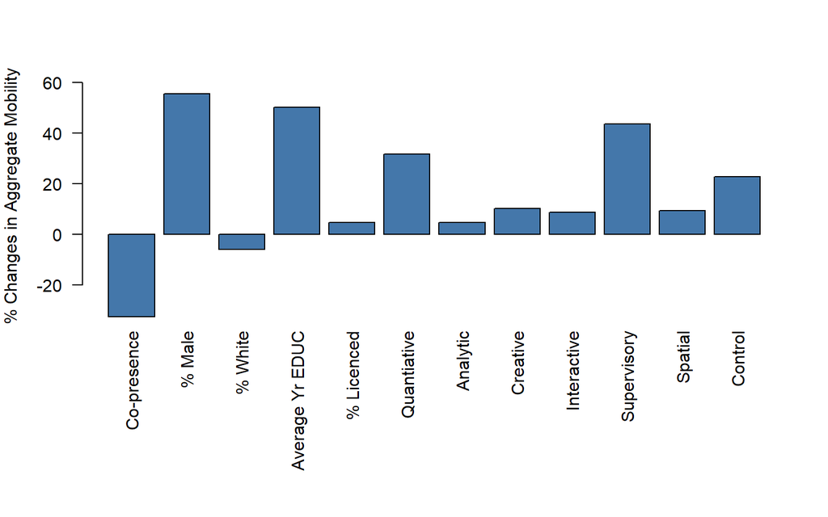

```r
cfm<-rep(0,12)
m<-as.matrix(cf)

for (i in 4:15){
  j<-i-3
  no<-as.vector(m[,i])
  cfm[j]<-weighted.mean(no, m[,16])
}

change<-(cfm-ob)/ob*100

par(mar=c(10,4,4,2))
barplot(change,names.arg = c("Co-presence",lab),las=2,ylim=c(-30,60),
        ylab="% Changes in Aggregate Mobility",col=pcolor1[1])
```

### Occupational Similarities

It is possible that the co-presence is driven by occupational similarities that are not captured by the general skill measures. To test this possibility, we incorporate two additional controls from O*NET. The first is relatedness, describing how similar the work content and activities are between a pair of occupations. The second is knowledge cosine, describing to what extent the two occupations share the same domain-specific knowledge. Both are expected to be positively associated with mobility and attenuate the coefficients we saw in the previous table.

To be clear, since learning domain-specific knowledge could be a consequence of working in the same workplace, it could be understood as a mediator instead of a confounder.

```r
t1<-read.csv("table_all_relate.csv")
qap<-read_dta("dist_qap_all_relate.dta")
qap<-as.matrix(qap)
coef<-read_dta("coef_all_relate.dta")
coef<-as.numeric(coef[1,])

t1<-cbind(t1,NA)
colnames(t1)<-c("Variable","Coefficent","Clstr SE P-value","QAP Percentile")


lab<-c("% Male"," % White","Average Yr EDUC","% Licenced",
       "Quantiative","Analytic","Creative","Interactive","Supervisory",
       "Spatial","Control","Relatedness","Knowledge")
loc<-2+length(lab)
t1[2:loc,1]<-c("Co-presence",lab)

for (i in 1:14){
  percentile <- ecdf(qap[,i])
  ptile<-percentile(coef[i])
  t1[i+1,4]<-ptile
}


knitr::kable(t1)
```

| Variable | Coefficent | Clstr SE P-value | QAP Percentile |
| --- | --- | --- | --- |
| = | =flow | = | NA |
| Co-presence | =3.516*** | =(0.000) | 1.000 |
| % Male | =-0.0352*** | =(0.000) | 0.002 |
| % White | =0.00253 | =(0.877) | 0.560 |
| Average Yr EDUC | =-0.00293* | =(0.027) | 0.125 |
| % Licenced | =-0.00224 | =(0.750) | 0.451 |
| Quantiative | =-0.00984*** | =(0.000) | 0.004 |
| Analytic | =-0.00327 | =(0.316) | 0.206 |
| Creative | =-0.000613 | =(0.771) | 0.421 |
| Interactive | =0.00540 | =(0.069) | 0.920 |
| Supervisory | =-0.0238*** | =(0.000) | 0.000 |
| Spatial | =0.000641 | =(0.787) | 0.553 |
| Control | =-0.00350 | =(0.204) | 0.221 |
| Relatedness | =0.0535*** | =(0.000) | 1.000 |
| Knowledge | =0.221* | =(0.027) | 0.896 |
| =_cons | =-0.117 | =(0.206) | NA |
| =N | =34410 | = | NA |
| =R-sq | =0.110 | = | NA |
| =p-values in parentheses |  |  | NA |
| =* p<0.05, ** p<0.01, *** p<0.001 |  |  | NA |

The inclusion of these two additional measures does attenuate the coefficient for co-presence but the latter is still robustly correlated with mobility. Among the skill measures, differences in quantitative and supervisory skills remain robustly correlated with mobility.

## By Mobility Type

As discussed above, the effect of co-presence is likely to vary by mobility. I therefore modify the previous equation and add both mobility type $T_{i->j}$ and its interaction with co-presence:

$$F_{i->j}=O_{i->j}+T_{i->j}+O_{i->j}*T_{i->j}+|D_{i}-D_{j}|+C_{j}+|S_{i}-S_{j}|$$

```r
t1<-read.csv("table_by_mob.csv")
qap<-read_dta("dist_qap_mob.dta")
qap<-as.matrix(qap)
coef<-read_dta("coef_mob.dta")
coef<-as.numeric(coef[1,-c(2,5)])
t1<-t1[-c(1,3,6),]
row.names(t1) <- NULL

t1<-cbind(t1,NA)
colnames(t1)<-c("Variable","Coefficent","Clstr SE P-value","QAP Percentile")


lab<-c("co-presence","Lateral","Upward","Co-presence*Lateral","Co-presence*Upward",
       "% Male"," % White","Average Yr EDUC","% Licenced",
       "Quantiative","Analytic","Creative","Interactive","Supervisory",
       "Spatial","Control")
loc<-length(lab)
t1[1:loc,1]<-c(lab)

for (i in 1:loc){
  percentile <- ecdf(qap[,i])
  ptile<-percentile(coef[i])
  t1[i,4]<-ptile
}


knitr::kable(t1)
```

| Variable | Coefficent | Clstr SE P-value | QAP Percentile |
| --- | --- | --- | --- |
| co-presence | =3.171*** | =(0.000) | 1.000 |
| Lateral | =0.0137 | =(0.127) | 0.971 |
| Upward | =-0.00716 | =(0.117) | 0.090 |
| Co-presence*Lateral | =2.930 | =(0.147) | 0.998 |
| Co-presence*Upward | =3.788** | =(0.004) | 1.000 |
| % Male | =-0.0823*** | =(0.000) | 0.000 |
| % White | =0.0286* | =(0.042) | 0.877 |
| Average Yr EDUC | =-0.0124*** | =(0.000) | 0.000 |
| % Licenced | =-0.0117 | =(0.129) | 0.196 |
| Quantiative | =-0.0144*** | =(0.000) | 0.000 |
| Analytic | =0.000698 | =(0.793) | 0.518 |
| Creative | =-0.00392 | =(0.069) | 0.127 |
| Interactive | =-0.00439 | =(0.084) | 0.114 |
| Supervisory | =-0.0189*** | =(0.000) | 0.000 |
| Spatial | =-0.00381 | =(0.118) | 0.155 |
| Control | =-0.0110*** | =(0.000) | 0.004 |
| =_cons | =0.148*** | =(0.000) | NA |
| =N | =34782 | = | NA |
| =R-sq | =0.094 | = | NA |
| =p-values in parentheses |  |  | NA |
| =* p<0.05, ** p<0.01, *** p<0.001 |  |  | NA |

The estimates here are consistent with the expectation that co-presence has stronger effect for upward mobility.

I can also estimate separate models for each type of mobility but I won’t be able to produce QAP estimates for non-square matrices.

We can now conduct a similar analysis to see how much co-presence attributes to each type of mobility.

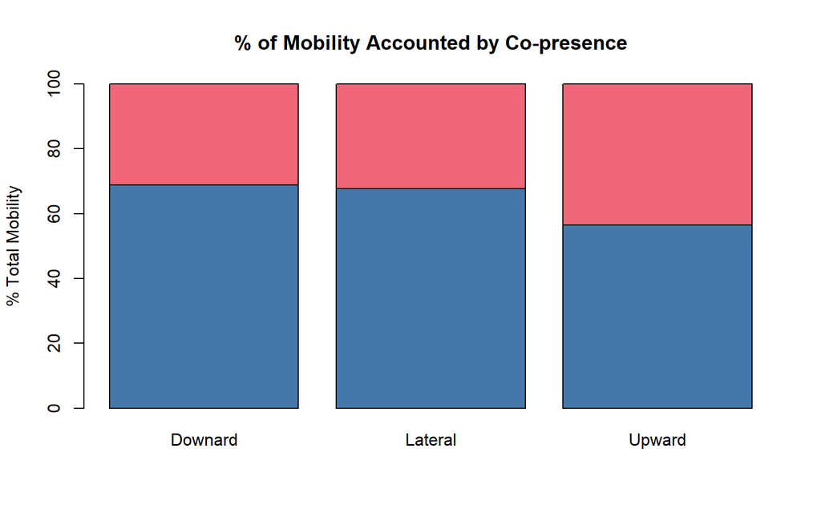

```r
cf1<-read_dta("counterfactual_1.dta")
cf2<-read_dta("counterfactual_2.dta")
cf3<-read_dta("counterfactual_3.dta")

ob1<-weighted.mean(cf1$ob, cf1$sendsize)
noexp1<-weighted.mean(cf1$cf, cf1$sendsize)
dif1<-ob1-noexp1

ob2<-weighted.mean(cf2$ob, cf2$sendsize)
noexp2<-weighted.mean(cf2$cf, cf2$sendsize)
dif2<-ob2-noexp2

ob3<-weighted.mean(cf3$ob, cf3$sendsize)
noexp3<-weighted.mean(cf3$cf, cf3$sendsize)
dif3<-ob3-noexp3

m<-matrix(c(1-dif1/ob1,dif1/ob1,1-dif2/ob2,dif2/ob2,1-dif3/ob3,dif3/ob3),byrow=F,ncol=3)

barplot(m*100,
        col=pcolor1[1:2],names.arg = c("Downard","Lateral","Upward"),ylab="% Total Mobility", ylim=c(0,100), main="% of Mobility Accounted by Co-presence")
```

The figure shows that co-presence accounts for 31.092 % of total downward mobility, 32.362 % of total lateral mobility, and 43.462 % of total upward mobility. I think these are pretty large numbers.

## Co-presence and Skill Gaps

The last set of analysis focuses on how the effect of co-presence could be contingent on occupational differences. We would expect that the effect of co-presence to be higher when the occupations are more similar and lower when the occupations are less similar. The dissimilarity could be so large that renders co-presence irrelevant. I think it would be interesting to see at what point co-presence no longer promotes mobility but I am curious about whether you find it interesting/meaningful.

Essentially, I plan to add interaction terms between co-presence and each skill difference to allow the association between co-presence and mobility to vary by skill difference (or vice versa). I will then plot the predicted flows of having zero co-presence and that of having 10 percent of workers by skill difference, from no difference to 4 standard deviation of difference.

I will focus only on upward mobility for this set of analysis due to its importance and the ease of interpretation (skill difference tends to mean deficiency, not excess, in comparison to the destination occupation).

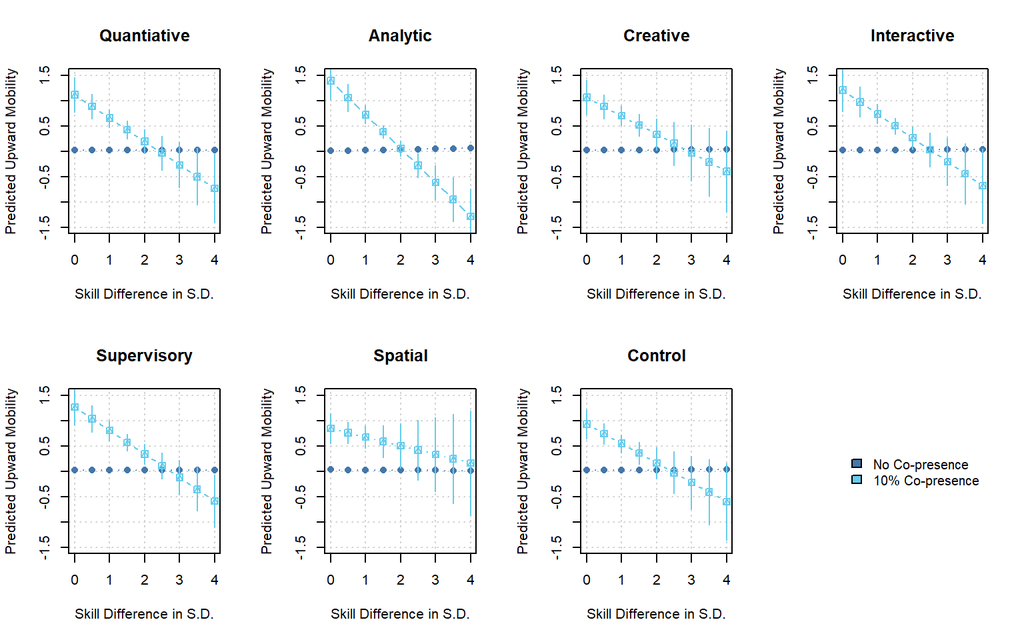

```r
est<-read_dta("inter_estimates.dta")
m<-as.matrix(est)
lab<-c("Quantiative","Analytic","Creative","Interactive","Supervisory",
       "Spatial","Control")

xcord<-seq(0,4,0.5)

par(mfrow=c(2,4))
k<-1
for (i in seq(1,25,4)){
j<-i+2
plot(xcord,m[,i],type="b",pch=16,
     ylim=c(-1.5,1.5),
     xlab="Skill Difference in S.D.",ylab="Predicted Upward Mobility",main=lab[k])
grid()
points(xcord,m[,i],type="b",pch=16,col=pcolor1[1])
points(xcord,m[,j],type="b",pch=14,col=pcolor1[5])
segments(xcord,m[,i]+1.96*m[,i+1],xcord,m[,i]-1.96*m[,i+1],col=pcolor1[1])
segments(xcord,m[,j]+1.96*m[,j+1],xcord,m[,j]-1.96*m[,j+1],col=pcolor1[5])
box()
k<-k+1
}

plot.new()
legend("center",c("No Co-presence","10% Co-presence"),
       fill=c(pcolor1[1],pcolor1[5]),bty="n",cex=0.95)
```

The “No Co-presence” estimates do have error bars but they are very small because there are many observations with a co-presence of zero.

Second, skill differences do not move mobility much when there is no co-presence. That is, in the absence of co-presence, no matter how big or small the skill difference is, the mobility is always close to zero.

This is a rather interesting outcome to me because it shows that firms may be fundamental to skill differentiation and sorting. Even if the origin and destination occupations have very similar skill contents, there would not be much upward mobility unless the two occupations situated in same workplaces.